# Question

Un administrador de un plaza de comidas está analizando la asistencia a las 5 restaurantes. Los datos se muestran en la tabla, donde uno de los valores se representa como “N”.

Si la mediana del conjunto completo de datos es 537 y no hay dos restaurantes con el mismo número de comensales, **formule y resuelva** el problema para determinar el valor de N.

**¿Cuál de las siguientes afirmaciones presenta la formulación y solución CORRECTA?**

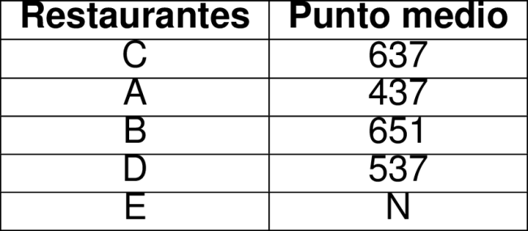

## Answerlist

- N = 494 porque debe ser el menor valor posible del conjunto
- N = 585 porque debe ser mayor que la mediana para equilibrar los valores
- N = 536 porque debe ser menor que 537 para que este valor quede en la posición central
- N = 651 porque debe coincidir con uno de los valores extremos

# Solution

Para resolver este problema de **formulación y ejecución matemática**, debemos plantear el problema, identificar las condiciones y aplicar el procedimiento correcto para encontrar el valor de N.

### Formulación del problema

**Datos dados:** - Tenemos 5 restaurantes: C, A, B, D, E - Sus valores son: 637, 437, 651, 537, N - La mediana del conjunto completo es 537 - No hay dos valores iguales (condición de unicidad)

**Problema a formular:** Determinar el valor de N que satisface la condición de mediana.

### Análisis de la formulación correcta

**¿Por qué esta formulación es correcta?**

- Identifica correctamente la condición matemática para la mediana
- Aplica el procedimiento apropiado según el número de datos (impar)
- Establece la relación correcta entre N y los demás valores
- Llega a la solución mediante un razonamiento matemático válido

**¿Por qué las otras formulaciones son incorrectas?**

- Confunden conceptos estadísticos (mediana vs. media, posición vs. valor)
- Aplican procedimientos incorrectos para el cálculo de la mediana
- No consideran adecuadamente la condición de ordenamiento
- Presentan errores en la interpretación del problema

### Concepto de mediana

La mediana de 5 valores ordenados de menor a mayor es el valor que ocupa la **posición central (posición 3 )**.

Para que la mediana sea 537 , cuando ordenemos los 5 valores de menor a mayor, el valor en la posición 3 debe ser exactamente 537 .

### Análisis de casos

Los valores conocidos son: 437, 651, 637, 537

Analicemos dónde puede ubicarse N para que la mediana sea 537:

**Caso 3:** Si N = 537 - No es válido porque no puede haber valores iguales

**Caso 4:** Si N > 537 - El valor 537 no estaría en posición 3 - Mediana diferente de 537

### Conclusión

El **mayor valor posible** para N es ** 536 ** (justo menor que 537 ).

# Meta-information

exname: mediana_formulacion_estadistica extype: schoice exsolution: 0010 exshuffle: TRUE exsection: Estadística|Medidas de posición|Mediana|Formulación exextra[Type]: Formulación y ejecución exextra[Level]: 2 exextra[Language]: es exextra[Course]: Matemáticas ICFES